# Introduction to the San Francisco Case Study and Dataset

Part 1 of ISEE pre-conference workshop Interrupted Time Series Analysis in Environmental Epidemiology: An Overview of Traditional and Novel Modeling Approaches

Tarik Benmarhnia, Yiqun Ma

2026-08-30

# Learning objectives

By the end of this section, you should be able to:

1. Understand the background of the case study.
2. State the study question and target counterfactual.
3. Understand the meaning and role of each variable.
4. Describe the wildfire smoke event before estimating its respiratory health impacts.

# Case-study background

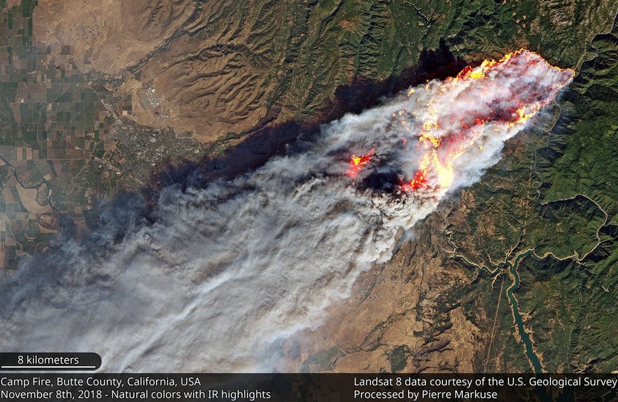

2018 Camp Fire in California

The Camp Fire ignited in Butte County, California, on November 8, 2018. Although San Francisco is more than 150 miles southwest of the ignition source, wildfire smoke substantially affected the city. Daily mean total PM2.5 concentrations in San Francisco exceeded 35 micrograms per cubic meter for 12 consecutive days, from November 9 through November 20, and reached a peak of 105 micrograms per cubic meter.

**Study question:** How many respiratory hospitalizations occurred during the smoke event beyond the number that would have been expected had the smoke event not occurred?

**Target counterfactual:** The daily respiratory hospitalization trajectory in San Francisco during November 9–20, 2018, if the wildfire smoke event had not occurred.

**This case is well-suited for an interrupted time series analysis because:**

1. the smoke event began at a clearly defined time point;
2. respiratory hospitalizations are an acute outcome that could respond rapidly;
3. daily outcome data are available for several years before the event; and
4. a directly comparable unexposed population may be difficult to define.

Source: [Ma, Y., & Benmarhnia, T. (2025). Interrupted time series analysis in environmental epidemiology: A review of traditional and novel modeling approaches. Current Environmental Health Reports, 12(1), 50.](https://link.springer.com/article/10.1007/s40572-025-00517-3).

# Load required packages

```r
library(tidyverse)
library(patchwork)
library(scales)
```

# Read and prepare the data

```r
## load the case study dataset "data_case_study_11to18.RDS" using its file path in your device

data <- readRDS(params$data_path) %>%
  mutate(
    date = as.Date(date),
    dow = as.factor(dow)) %>%
  arrange(date)
```

# Examine the data

```r
summary(data)
```

```
##       date                 time        dow          doy
##  Min.   :2011-01-01   Min.   :   1.0   1:418   Min.   :  1.0
##  1st Qu.:2012-12-31   1st Qu.: 731.2   2:418   1st Qu.: 92.0
##  Median :2014-12-31   Median :1461.5   3:417   Median :183.0
##  Mean   :2014-12-31   Mean   :1461.5   4:417   Mean   :183.1
##  3rd Qu.:2016-12-30   3rd Qu.:2191.8   5:417   3rd Qu.:274.0
##  Max.   :2018-12-31   Max.   :2922.0   6:417   Max.   :366.0
##                                        7:418
##      event           respiratory      PM25_total         PM25_smk
##  Min.   :0.000000   Min.   : 13.0   Min.   :  1.867   Min.   : 0.0000
##  1st Qu.:0.000000   1st Qu.: 40.0   1st Qu.:  6.049   1st Qu.: 0.0000
##  Median :0.000000   Median : 50.0   Median :  7.679   Median : 0.0000
##  Mean   :0.004107   Mean   : 53.4   Mean   :  8.899   Mean   : 0.5509
##  3rd Qu.:0.000000   3rd Qu.: 63.0   3rd Qu.: 10.002   3rd Qu.: 0.0000
##  Max.   :1.000000   Max.   :141.0   Max.   :105.783   Max.   :97.7392
##
##   PM25_nonsmk         Tmean              RH             Prcp
##  Min.   : 1.867   Min.   : 5.111   Min.   :24.08   Min.   : 0.00
##  1st Qu.: 6.031   1st Qu.:12.670   1st Qu.:68.54   1st Qu.: 0.00
##  Median : 7.474   Median :14.630   Median :73.10   Median : 0.00
##  Mean   : 8.348   Mean   :14.507   Mean   :71.86   Mean   : 1.47
##  3rd Qu.: 9.524   3rd Qu.:16.300   3rd Qu.:76.86   3rd Qu.: 0.00
##  Max.   :29.694   Max.   :28.819   Max.   :95.59   Max.   :87.04
##
```

```r
dim(data)
```

```
## [1] 2922   12
```

```r
names(data)
```

```
##  [1] "date"        "time"        "dow"         "doy"         "event"
##  [6] "respiratory" "PM25_total"  "PM25_smk"    "PM25_nonsmk" "Tmean"
## [11] "RH"          "Prcp"
```

```r
range(data$date)
```

```
## [1] "2011-01-01" "2018-12-31"
```

```r
table(data$event)
```

```
##
##    0    1
## 2910   12
```

# Check the event period

```r
event_dates <- data %>%
  filter(event == 1) %>%
  pull(date)

event_start <- min(event_dates)
event_end   <- max(event_dates)
event_days  <- n_distinct(event_dates)

tibble(
  event_start = event_start,
  event_end = event_end,
  number_of_event_days = event_days
)
```

```
## # A tibble: 1 × 3
##   event_start event_end  number_of_event_days
##   <date>      <date>                    <int>
## 1 2018-11-09  2018-11-20                   12
```

# Dataset structure

```r
data_dictionary <- tribble(
  ~variable,      ~role,                         ~description,
  "date",         "Time index",                 "Calendar date",
  "time",         "Long-term trend",            "Number of days since the beginning of the study",
  "dow",          "Weekly pattern",             "Day of week",
  "doy",          "Annual seasonality",         "Day of year",
  "event",        "Event indicator",            "1 during event period; 0 otherwise",
  "respiratory",  "Outcome",                    "Daily count of respiratory hospitalizations",
  "PM25_total",   "Event characterization",     "Daily mean total PM2.5 concentration (micrograms per cubic meter)",
  "PM25_smk",     "Event characterization",     "Daily mean wildfire-smoke PM2.5 concentration (micrograms per cubic meter)",
  "PM25_nonsmk",  "Candidate predictor",        "Daily mean non-smoke PM2.5 concentration (micrograms per cubic meter)",
  "Tmean",        "Candidate predictor",        "Daily mean air temperature (Degrees Celsius)",
  "RH",           "Candidate predictor",        "Daily mean relative humidity (%)",
  "Prcp",         "Candidate predictor",        "Daily total precipitation (mm)"
)

knitr::kable(data_dictionary, align = c("l", "l", "l"))
```

| variable | role | description |
| --- | --- | --- |
| date | Time index | Calendar date |
| time | Long-term trend | Number of days since the beginning of the study |
| dow | Weekly pattern | Day of week |
| doy | Annual seasonality | Day of year |
| event | Event indicator | 1 during event period; 0 otherwise |
| respiratory | Outcome | Daily count of respiratory hospitalizations |
| PM25_total | Event characterization | Daily mean total PM2.5 concentration (micrograms per cubic meter) |
| PM25_smk | Event characterization | Daily mean wildfire-smoke PM2.5 concentration (micrograms per cubic meter) |
| PM25_nonsmk | Candidate predictor | Daily mean non-smoke PM2.5 concentration (micrograms per cubic meter) |
| Tmean | Candidate predictor | Daily mean air temperature (Degrees Celsius) |
| RH | Candidate predictor | Daily mean relative humidity (%) |
| Prcp | Candidate predictor | Daily total precipitation (mm) |

# Basic temporal and data-quality checks

```r
quality_summary <- data %>%
  summarise(
    first_date = min(date),
    last_date = max(date),
    number_of_days = n(),
    duplicate_dates = sum(duplicated(date)),
    gaps_in_daily_series = sum(as.numeric(date - lag(date)) > 1, na.rm = TRUE),
    event_days = sum(event == 1, na.rm = TRUE)
  )

print(quality_summary, width = Inf)
```

```
## # A tibble: 1 × 6
##   first_date last_date  number_of_days duplicate_dates gaps_in_daily_series
##   <date>     <date>              <int>           <int>                <int>
## 1 2011-01-01 2018-12-31           2922               0                    0
##   event_days
##        <int>
## 1         12
```

```r
missing_summary <- data %>%
  summarise(across(everything(), ~ sum(is.na(.x)))) %>%
  pivot_longer(
    cols = everything(),
    names_to = "variable",
    values_to = "missing_values"
  )

missing_summary
```

```
## # A tibble: 12 × 2
##    variable    missing_values
##    <chr>                <int>
##  1 date                     0
##  2 time                     0
##  3 dow                      0
##  4 doy                      0
##  5 event                    0
##  6 respiratory              0
##  7 PM25_total               0
##  8 PM25_smk                 0
##  9 PM25_nonsmk              0
## 10 Tmean                    0
## 11 RH                       0
## 12 Prcp                     0
```

Questions:

1. Is there exactly one observation per day?
2. Are there gaps in the time series?
3. Are there missings in predictor values?
4. Is the event indicator consistent with the prespecified event dates?

# Descriptive summary around the event

```r
display_start <- event_start - 30
display_end   <- event_end + 30

data_event_context <- data %>%
  filter(date >= display_start, date <= display_end) %>%
  mutate(
    period = case_when(
      date < event_start ~ "30 days before",
      event == 1 ~ "Smoke-event period",
      date > event_end ~ "30 days after"
    ),
    period = factor(
      period,
      levels = c("30 days before", "Smoke-event period", "30 days after")
    )
  )

period_summary <- data_event_context %>%
  group_by(period) %>%
  summarise(
    days = n(),
    mean_daily_respiratory = mean(respiratory, na.rm = TRUE),
    mean_smoke_PM25 = mean(PM25_smk, na.rm = TRUE),
    mean_nonsmoke_PM25 = mean(PM25_nonsmk, na.rm = TRUE),
    .groups = "drop"
  )

knitr::kable(period_summary, digits = 1)
```

| period | days | mean_daily_respiratory | mean_smoke_PM25 | mean_nonsmoke_PM25 |
| --- | --- | --- | --- | --- |
| 30 days before | 30 | 41.3 | 0.2 | 9.1 |
| Smoke-event period | 12 | 61.5 | 66.7 | 8.9 |
| 30 days after | 30 | 54.9 | 0.0 | 8.5 |

# PM2.5 surrounding the smoke event

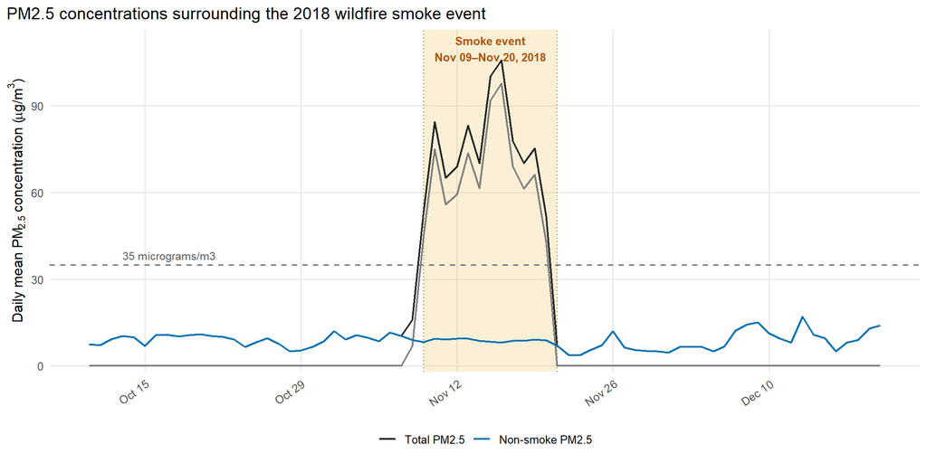

```r
event_band <- tibble(
  xmin = event_start,
  xmax = event_end + 1
)

data_pm_event <- data %>%
  filter(date >= display_start, date <= display_end) %>%
  select(date, PM25_total, PM25_smk, PM25_nonsmk) %>%
  pivot_longer(
    cols = starts_with("PM25_"),
    names_to = "pm_series",
    values_to = "PM25"
  ) %>%
  mutate(
    pm_series = recode(
      pm_series,
      PM25_total = "Total PM2.5",
      PM25_smk = "Smoke PM2.5",
      PM25_nonsmk = "Non-smoke PM2.5"
    ),
    pm_series = factor(
      pm_series,
      levels = c("Total PM2.5", "Smoke PM2.5", "Non-smoke PM2.5")
    )
  )

event_fill <- "#E69F00"
event_line <- "#B45309"
outcome_color <- "#2C3E50"
total_pm_color <- "#252525"
smoke_pm_color <- "#D55E00"
nonsmoke_pm_color <- "#0072B2"

p_pm25 <- ggplot(data_pm_event, aes(x = date, y = PM25, color = pm_series)) +
  geom_rect(
    data = event_band,
    aes(xmin = xmin, xmax = xmax, ymin = -Inf, ymax = Inf),
    inherit.aes = FALSE,
    fill = event_fill,
    alpha = 0.16,
    color = NA
  ) +
  geom_hline(
    yintercept = 35,
    color = "grey45",
    linetype = "dashed",
    linewidth = 0.6
  ) +
  geom_line(linewidth = 0.8) +
  geom_vline(
    xintercept = as.numeric(c(event_start, event_end + 1)),
    color = event_line,
    linetype = "dotted",
    linewidth = 0.5
  ) +
  annotate(
    "text",
    x = display_start + 3,
    y = 35,
    label = "35 micrograms/m3",
    hjust = 0,
    vjust = -0.6,
    color = "grey35",
    size = 3.3
  ) +
  annotate(
    "text",
    x = event_start + (event_end - event_start) / 2,
    y = Inf,
    label = paste0(
      "Smoke event\n",
      format(event_start, "%b %d"), "–", format(event_end, "%b %d, %Y")
    ),
    hjust = 0.5,
    vjust = 1.25,
    color = event_line,
    fontface = "bold",
    size = 3.4
  ) +
  scale_color_manual(
    values = c(
      "Total PM2.5" = total_pm_color,
      "Wildfire-smoke PM2.5" = smoke_pm_color,
      "Non-smoke PM2.5" = nonsmoke_pm_color
    )
  ) +
  scale_x_date(date_breaks = "2 weeks", date_labels = "%b %d") +
  scale_y_continuous(expand = expansion(mult = c(0.02, 0.10))) +
  labs(
    title = "PM2.5 concentrations surrounding the 2018 wildfire smoke event",
    x = NULL,
    y = expression("Daily mean PM"[2.5]~"concentration ("*mu*"g/m"^3*")"),
    color = NULL
  ) +
  theme(
    legend.position = "bottom",
    axis.text.x = element_text(angle = 35, hjust = 1)
  )

p_pm25
```

# Descriptive figure highlighting the event

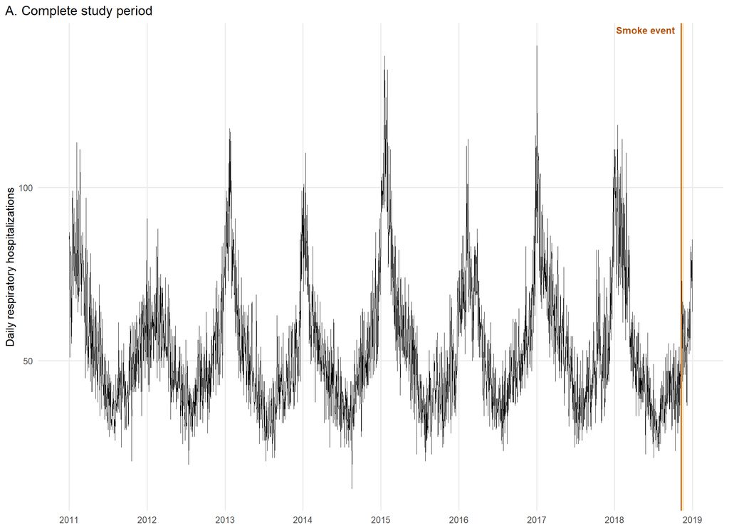

```r
p_full <- ggplot(data, aes(x = date, y = respiratory)) +
  geom_rect(
    data = event_band,
    aes(xmin = xmin, xmax = xmax, ymin = -Inf, ymax = Inf),
    inherit.aes = FALSE,
    fill = event_fill,
    alpha = 0.28
  ) +
  geom_line(linewidth = 0.25) +
  geom_vline(
    xintercept = as.numeric(event_start),
    color = event_line,
    linewidth = 0.6
  ) +
  annotate(
    "text",
    x = event_start - 30,
    y = Inf,
    label = "Smoke event",
    hjust = 1,
    vjust = 1.4,
    color = event_line,
    fontface = "bold",
    size = 3.5
  ) +
  scale_x_date(date_breaks = "1 year", date_labels = "%Y") +
  labs(
    title = "A. Complete study period",
    x = NULL,
    y = "Daily respiratory hospitalizations"
  )

p_full
```

You can see a clear seasonal pattern in respiratory hospitalizations.

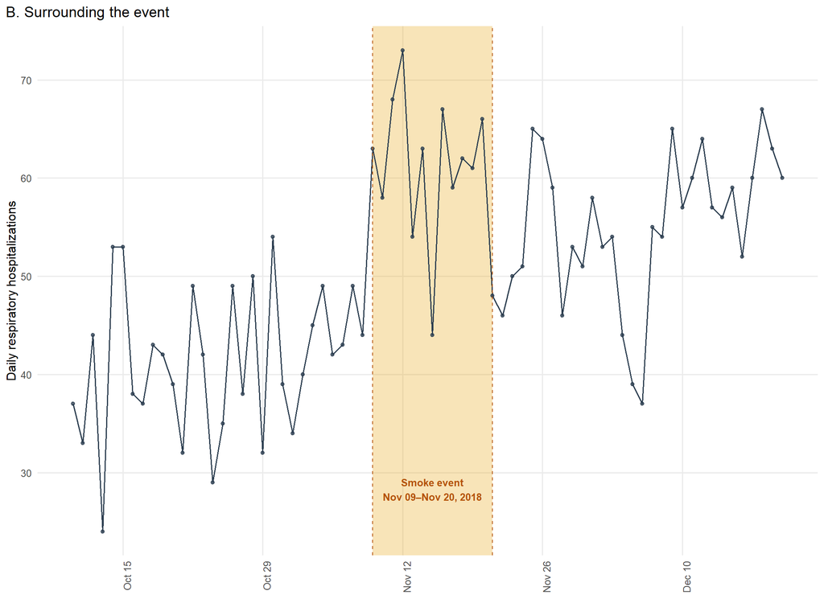

```r
p_zoom <- data %>%
  filter(date >= display_start, date <= display_end) %>%
  ggplot(aes(x = date, y = respiratory)) +
  geom_rect(
    data = event_band,
    aes(xmin = xmin, xmax = xmax, ymin = -Inf, ymax = Inf),
    inherit.aes = FALSE,
    fill = event_fill,
    alpha = 0.28
  ) +
  geom_line(color = outcome_color, linewidth = 0.55) +
  geom_point(color = outcome_color, size = 1.4, alpha = 0.75) +
  geom_vline(
    xintercept = as.numeric(c(event_start, event_end + 1)),
    color = event_line,
    linetype = "dashed",
    linewidth = 0.5
  ) +
  annotate(
    "text",
    x = event_start + (event_end - event_start) / 2,
    y = 30,
    label = paste0(
      "Smoke event\n",
      format(event_start, "%b %d"), "–", format(event_end, "%b %d, %Y")
    ),
    hjust = 0.5,
    vjust = 1.25,
    color = event_line,
    fontface = "bold",
    size = 3.4
  ) +
  scale_x_date(date_breaks = "2 weeks", date_labels = "%b %d") +
  labs(
    title = "B. Surrounding the event",
    x = NULL,
    y = "Daily respiratory hospitalizations"
  ) +
  theme(axis.text.x = element_text(angle = 90, hjust = 1))

p_zoom
```

# Questions:

1. Why do we only use non-smoke PM2.5 as a candidate predictor? Why not total PM2.5 or smoke PM2.5?
2. Why can’t we simply use the mean of the preceding 30 days as the counterfactual?